# Probabilistic Graphical Models: Homework 1

Mohamed N'AITN'BARK

```python
import pandas as pd
import numpy as np
import matplotlib
import pylab
from numpy import linalg
```

```python
%matplotlib inline
```

## I - Learning in discrete graphical models

**Maximum likelihood for the r.a. z:**  
Let's code our $ (z_m)_{m \in [1,M]} $ by vectors of dimension $ M $ such that $ \forall m, i : z_m^{(i)} = \delta_{m,i}$ where $\delta$ is the Kronecker symbol and $ z_m^{(i)} $ the ith components of the vector $z_m$.  
Then we can write $P(z) = \prod_{m \in [1,M]}{\pi_m^{z^{(m)}}}$ and then our likelihood function is: $L(z_1,..,z_n,\pi) = \prod_{i \in [1,N]}{\prod_{m \in [1,M]}{\pi_m^{z_i^{(m)}}}}$. Hence the log-likelihood is $l(z_1,..,z_n,\pi) = \sum_{i \in [1,N]}{\sum_{m \in [1,M]}{z_i^{(m)}log(\pi_m)}}$. Then we can formulate the maximum likelihood estimator $\pi^{MV}$ as the solution of the problem:$argmax_{\pi}{\sum_{i \in [1,N]}{\sum_{m \in [1,M]}{z_i^{(m)}log(\pi_m)}}} \\s.t. \forall m \in [1,M]: \pi_m \geq 0\ and \sum_{m \in [1,M]}{\pi_m} = 1$ $l(z_1,..,z_n,\pi) = \sum_{i \in [1,N]}{\sum_{m \in [1,M]}{z_i^{(m)}log(\pi_m)}} = \sum_{m \in [1,M]}{(\sum_{i \in [1,n]}{z_i^{(m)})log(\pi_m)}} = \sum_{m \in [1,M]}{n_{m}log(\pi_m)}$ Where $n_m = card\{i | z_i^{m} = 1\}$  
Then the lagrangian of our problem is $L(\pi,\lambda) = - \sum_{m \in [1,M]}{n_{m}log(\pi_m)} + \lambda (\sum_{k \in [1,K]}{\pi_k} - 1)$  
$L(\pi,\lambda)$ is a convex function, and for example $\frac{1}{K}$ **1** $\in ]0;+\infty[^K \cap \{\pi | sum_{k \in [1,K]}{pi_k} = 1\}$ then by Slater's constraint qualification lemma:  
$\max_{\pi}{l(\pi)} = \max_{\lambda}{\min_{\pi}{L(\pi,\lambda)}}$  
$\frac{\partial L}{\partial \pi_{m}} = - \frac{\pi_m}{n_m} + \lambda \Rightarrow \pi_m = \frac{n_m}{\lambda}$  
The constraint $\sum_{m \in [1,M]}{\pi_m} = 1$ gives $\lambda = n$ therefore: $\forall m \in [1,M]: \pi_m = \frac{n_m}{n}$

**Maximum likelihood for the r.a. x:**  
An analogous derivation as below shows that our log-likelihood is given by: $l(x_1,..,x_n|z_1,...,z_n,\theta) = \sum_{i \in [1,n]}{\sum_{m \in [1,M]}{\sum_{k \in [1,K]}{x_i^{(k)}z_i^{(m)}log(\theta_m^k)}}}$. Again we can write the loglikelihood in the form: $l(x_1,..,x_n|z_1,...,z_n,\theta) = \sum_{k \in [1,K]}{\sum_{m \in [1,M]}{(\sum_{i \in [1,n]}{x_i^{(k)}z_i^{(m)}})log(\theta_m^k)}} = \sum_{k \in [1,K]}{\sum_{m \in [1,M]}{n_m^k log(\theta_m^k)}}$.  
Where $n_m^k = \sum_{i \in [1,n]}{x_i^{(k)}z_i^{(m)}}$.  
This is the same problem as above and by using the same arguments as in the case of $z$ we derive the MV estimator ($n_m = \sum_{k \in [1,K]}{n_m^k}$):$\theta_m^k = \frac{n_m^k}{n_m}$

## II - Linear classification

### 1 - Generative model (LDA)

** (a) **  
The probability of having a realisation $(x,y)$ is $p(x,y;\pi;\mu) = p(x|y;\pi;\mu) = \prod_{k \in [1,K]}{(\pi_k f{(x,\mu_k)})^{y^{(k)}}}$ where $f{(x,\mu_k)}$ is the normal density function $N(\mu_k, \Sigma)$.  
Then the log-likelihood of our model is given by: $l(\pi,\mu) = \sum_{n \in [1,N]}{\sum_{k \in [1,K]}{y_n^{(k)}[-\frac{1}{2}(x_n - \mu_k)^T \Sigma^{-1} (x_n - \mu_k) + log(\pi_k)]}} - Nlog(2\pi) - \frac{N}{2}log(\det{\Sigma}) \\ s.t \sum_{k \in [1,K]}{\pi_k} = 1$ The lagrangian of this problem is $L(\pi,\mu,\lambda) = - \sum_{n \in [1,N]}{\sum_{k \in [1,K]}{y_n^{(k)}[-\frac{1}{2}(x_n - \mu_k)^T \Sigma^{-1} (x_n - \mu_k) + log(\pi_k)]}} + \lambda (\sum_{k \in [1,K]}{\pi_k} - 1)$.  
The lagrangian is clearly a convex function and the condition of the Slater's constraint lemma is obviously verified, so we can write: $\max_{\pi,\mu}l(\pi,\mu) = \max_{\lambda}{\min_{\pi,\mu}{L(\pi,\mu,\lambda)}}$ $\forall k \in [1,K]: \frac{\partial L}{\partial \pi_k} = \frac{\sum_{n \in [1,N]}{y_n^{(k)}}}{2 \pi_k} + \lambda = 0 \Rightarrow \pi_k = \frac{\sum_{n \in [1,N]}{y_n^{(k)}}}{2 \lambda}$  
Since $\sum_{k \in [1,K]}{\pi_k} = 1$ we get $\lambda = \frac{N}{2}$ and: $\forall k \in [1,K]: \pi_k = \frac{n_k}{N}\\ n_k = \sum_{n \in [1,N]}{y_n^{(k)}}$ $\forall k \in [1,K]: \frac{\partial L}{\partial \mu_k} = \sum_{n \in [1,N]}{y_n^{(k)}(x_n - \mu_k)} = 0 \Rightarrow \mu_k = \frac{\sum_{n \in [1,N]}{y_n^{(k)} x_n}}{N}$

** (b) **  
In the case of y Bernoulli r.a. :  
Using Bayes formula: $P(y=1|x) = \frac{P(x|y=1)P(y=1)}{P(x|y=1)P(y=1) + P(x|y=2)P(y=2)}$ i.e. $P(y=1|x) = \frac{\pi_1\exp{-(\frac{(x - \mu_1)^T \Sigma^{-1} (x - \mu_1)}{2})}}{\pi_1\exp{-(\frac{(x - \mu_1)^T \Sigma^{-1} (x - \mu_1)}{2})} + \pi_2\exp{-(\frac{(x - \mu_2)^T \Sigma^{-1} (x - \mu_2)}{2})}} = \frac{\frac{\pi_1}{\pi_2}\exp{(\beta x + \alpha)}}{\frac{\pi_1}{\pi_2}\exp{(\beta x + \alpha)} + 1}$ Where $\beta = \Sigma^{-1}(\mu_1 - \mu_2)$ and $\alpha = \frac{1}{2}(\mu_2\Sigma^{-1}\mu_2 - \mu_1\Sigma^{-1}\mu_1)$.  
This model corresponds to a logistic regression with parameters $\beta' = \beta$ and $\alpha' = \alpha + ln(\frac{\pi_1}{\pi_2})$

** (c) **

```python
data = np.loadtxt('./classification_data_HWK1/classificationA.train', delimiter="\t")
```

```python
class1 = data[data[:,2] == 0][:,(0,1)]
class2 = data[data[:,2] == 1][:,(0,1)]
```

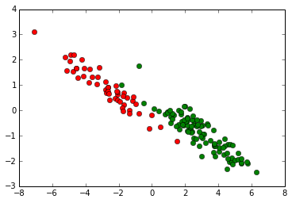

```python
pylab.plot(class1[:,0], class1[:,1], 'go', class2[:,0], class2[:,1], 'ro')
```

```python
#Estimate the parameters of our model
sigma = class1.T.dot(class1)/len(class1)
mean1 = class1.mean(0)
mean2 = class2.mean(0)
p1 = len(class1)/float(len(data))
p2 = 1-p1
```

```python
sigma
```

```
array([[ 10.71896757,  -3.63945951],
       [ -3.63945951,   1.37479476]])
```

```python
mean1
```

```
array([ 2.89970947, -0.893874  ])
```

```python
mean2
```

```
array([-2.69232004,  0.866042  ])
```

```python
p1
```

```
0.6666666666666666
```

```python
#Create a meshgrid to plot the bayesian separator
x = np.linspace(-15,15,200)
y = np.linspace(-15,15,200)
X0,Y0 = np.meshgrid(x, y)
```

```python
#Get the slope and intercept of the decision boundary (log(P(y=1|x)) = log(0.5))
def lda_train(x1,x2):
    mean1 = x1.mean(0)
    mean2 = x2.mean(0)
    sigma = (x1-mean1).T.dot(x1-mean1)/len(x1)
    inv_sigma = np.linalg.inv(sigma)
    beta_lda = inv_sigma.dot(mean1 - mean2)
    alpha_lda = 0.5*(mean2.T.dot(inv_sigma.dot(mean2)) - mean1.T.dot(inv_sigma.dot(mean1))) + np.log(p1/p2)
    return beta_lda, alpha_lda
```

```python
beta_lda, alpha_lda = lda_train(class2,class1)
```

```python
beta_lda
```

```
array([ -9.05944749, -14.53550779])
```

```python
alpha_lda
```

```
1.4302878470837002
```

```
<a list of 3 text.Text objects>
```

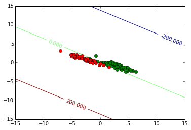

```python
# The decision function values on the meshgrid
Z0 = X0*beta_lda[0] + Y0*beta_lda[1] + alpha_lda
pylab.plot(class1[:,0], class1[:,1], 'go', class2[:,0], class2[:,1], 'ro')
cs = pylab.contour(X0,Y0,Z0,3)
pylab.clabel(cs)
```

### 2 - Logistic regression

```python
#Load data
from scipy.special import expit
tab_train = np.loadtxt('./classification_data_HWK1/classificationA.train', delimiter='\t')
```

```python
def split_data(data):
    X = data[:,(0,1)]
    X = np.append(X, np.ones((len(X),1)),1)
    Y = data[:,2]
    return X,Y
```

```python
# Separate the features from the target variables
X,Y = split_data(tab_train)
```

```python
#Implement the Newton Ralphson algorithm
def logreg_train(X,Y):
    #Init
    beta_logreg = (0,0,0)
    threshold = 0.001
    likelihood = []
    #Loop
    while True:
        likelihood.append((Y*np.log(expit(X.dot(beta_logreg))) +(1-Y)*np.log(1-expit(X.dot(beta_logreg)))).sum())
        beta_prev = beta_logreg
        J = X.T.dot(Y - expit(X.dot(beta_logreg)))
        R = np.diag( expit(X.dot(beta_logreg))*(1 - expit(X.dot(beta_logreg))) )
        H = -(X.T.dot(R)).dot(X)
        beta_logreg = beta_logreg - linalg.solve(H,J)
        if np.linalg.norm(beta_logreg - beta_prev)/np.linalg.norm(beta_prev) < threshold:
            break
    return beta_logreg, likelihood
```

```python
beta_logreg, likelihood = logreg_train(X,Y)
```

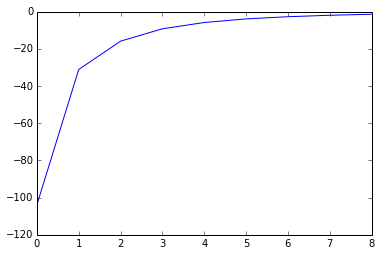

```python
pylab.plot(likelihood)
```

The graph above represents the log likelihood in each iteration of the optimization algorithm

```
<a list of 3 text.Text objects>
```

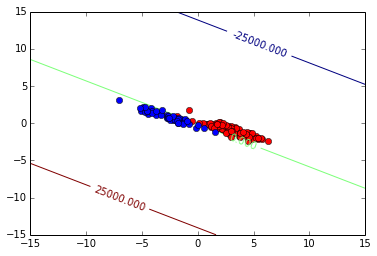

```python
Z0 = beta_logreg[0]*X0 + beta_logreg[1]*Y0 + beta_logreg[2]
pylab.plot(tab_train[Y == 0][:,0],tab_train[Y==0][:,1],'ro',tab_train[Y == 1][:,0],tab_train[Y==1][:,1],'bo')
cs = pylab.contour(X0,Y0,Z0,3)
pylab.clabel(cs)
```

### 3 - Linear regression

```python
# The linear regression model gives the expression of the parameter:
def lin_train(X,Y):
    return linalg.inv(X.T.dot(X)).dot(X.T).dot(Y)
```

```
<a list of 3 text.Text objects>
```

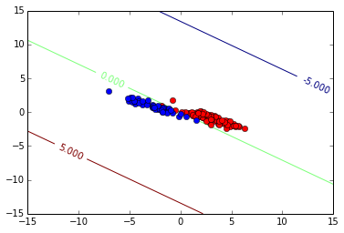

```python
#Now let's draw the data and the line with the equation <x,beta> = 0.5
beta_linreg = lin_train(X,Y)
Z0 = beta_linreg[0]*X0 + beta_linreg[1]*Y0 + beta_linreg[2] - 0.5
pylab.plot(tab_train[Y == 0][:,0],tab_train[Y==0][:,1],'ro',tab_train[Y == 1][:,0],tab_train[Y==1][:,1],'bo')
cs = pylab.contour(X0,Y0,Z0,3)
pylab.clabel(cs)
```

### 4 - Models performance

```python
# Let's define a function that computes misclafication error for linear models
def get_err(Y,X,beta,threshold):
    y_pred = (X.dot(beta) >= threshold)
    return np.mean(Y != y_pred)
```

**(a)** Performance of the implemented models on classifiactionA data set.

```python
# Loading test set
testA = np.loadtxt('./classification_data_HWK1/classificationA.test', delimiter='\t')
X_test, Y_test = split_data(testA)
```

```python
d = pd.DataFrame(data=np.zeros((6,4)), columns=['Set','lda','log_reg', 'lin_reg'])
d['Set'] = ['trainA','trainB','trainC','testA','testB','testC']
d = d.set_index('Set')
```

```python
# Error on training set
#LDA:
beta = np.array([beta_lda[0],beta_lda[1],alpha_lda])
d.ix['trainA','lda'] = get_err(Y,X,beta,0)
#Logistic regression
d.ix['trainA','log_reg'] = get_err(Y,X,beta_logreg,0)
# Linear regression
d.ix['trainA','lin_reg'] = get_err(Y,X,beta_linreg,0.5)

# Error on test set
d.ix['testA','lda'] = get_err(Y_test,X_test,beta,0)
#Logistic regression
d.ix['testA','log_reg'] = get_err(Y_test,X_test,beta_logreg,0)
# Linear regression
d.ix['testA','lin_reg'] = get_err(Y_test,X_test,beta_linreg,0.5)
```

**(b)** Now let's see how the three models perform on other data sets

```python
# Loading the data sets
train_B = np.loadtxt('./classification_data_HWK1/classificationB.train', delimiter='\t')
test_B = np.loadtxt('./classification_data_HWK1/classificationB.test', delimiter='\t')
train_C = np.loadtxt('./classification_data_HWK1/classificationC.train', delimiter='\t')
test_C = np.loadtxt('./classification_data_HWK1/classificationC.test', delimiter='\t')
X_b,Y_b = split_data(train_B)
X_c,Y_c = split_data(train_C)
X_test_b,Y_test_b = split_data(test_B)
X_test_c,Y_test_c = split_data(test_C)
```

```python
#Training the three models
#LDA
b,a = lda_train(X_b[Y_b==1][:,(0,1)],X_b[Y_b==0][:,(0,1)])
beta_b_lda = np.array([b[0],b[1],a])
b,a = lda_train(X_c[Y_c==1][:,(0,1)],X_c[Y_c==0][:,(0,1)])
beta_c_lda = np.array([b[0],b[1],a])
#Logistic regression
beta_b_log = logreg_train(X_b,Y_b)[0]
beta_c_log = logreg_train(X_c,Y_c)[0]
#Linear regression
beta_b_lin = lin_train(X_b,Y_b)
beta_c_lin = lin_train(X_c,Y_c)
```

```python
#Estimating misclassification error
#LDA:
d.ix['trainB','lda'] = get_err(Y_b,X_b,beta_b_lda,0)
d.ix['testB','lda'] = get_err(Y_test_b,X_test_b,beta_b_lda,0)
d.ix['trainC','lda'] = get_err(Y_b,X_b,beta_b_lda,0)
d.ix['testC','lda'] = get_err(Y_test_b,X_test_b,beta_b_lda,0)

#Logistic regression
d.ix['trainB','log_reg'] = get_err(Y_b,X_b,beta_b_log,0)
d.ix['testB','log_reg'] = get_err(Y_test_b,X_test_b,beta_b_log,0)
d.ix['trainC','log_reg'] = get_err(Y_c,X_c,beta_c_log,0)
d.ix['testC','log_reg'] = get_err(Y_test_c,X_test_c,beta_c_log,0)

# Linear regression
d.ix['trainB','lin_reg'] = get_err(Y_b,X_b,beta_b_lin,0.5)
d.ix['testB','lin_reg'] = get_err(Y_test_b,X_test_b,beta_b_lin,0.5)
d.ix['trainC','lin_reg'] = get_err(Y_c,X_c,beta_c_lin,0.5)
d.ix['testC','lin_reg'] = get_err(Y_test_c,X_test_c,beta_c_lin,0.5)
```

```python
d
```

| Set | lda | log_reg | lin_reg |
| --- | --- | --- | --- |
| trainA | 0.0200 | 0.000000 | 0.013333 |
| trainB | 0.1400 | 0.020000 | 0.030000 |
| trainC | 0.1400 | 0.040000 | 0.055000 |
| testA | 0.0360 | 0.034000 | 0.020667 |
| testB | 0.1525 | 0.043000 | 0.041500 |
| testC | 0.1525 | 0.022667 | 0.042333 |

**(d) Comments**

We see that the three models performs very well on the train sets, but comparing the results reveals that LDA is not suited to the data sets B and C. In the test set, logistic and linear regression are outperforming LDA.

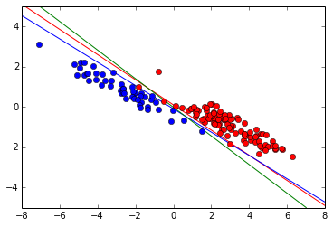

```python
x = np.linspace(-8,8,200)
y = np.linspace(-5,5,200)
X0,Y0 = np.meshgrid(x, y)
Z0 = X0*beta_lda[0] + Y0*beta_lda[1] + alpha_lda
Z1 = beta_logreg[0]*X0 + beta_logreg[1]*Y0 + beta_logreg[2]
Z2 = beta_linreg[0]*X0 + beta_linreg[1]*Y0 + beta_linreg[2] - 0.5
pylab.plot(X[Y==1][:,0],X[Y==1][:,1],'bo',X[Y==0][:,0],X[Y==0][:,1],'ro')
pylab.contour(X0,Y0,Z0,1,colors='r')
pylab.contour(X0,Y0,Z1,1,colors='b')
pylab.contour(X0,Y0,Z2,1,colors='g')
```

Data set A: LDA separator (red), Logistic regression separator (blue), Linear regression separator (green)

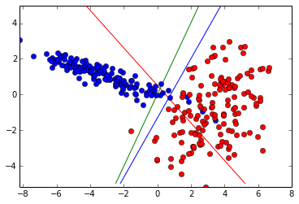

```python
x = np.linspace(-8,8,200)
y = np.linspace(-5,5,200)
X0,Y0 = np.meshgrid(x, y)
Z0 = X0*beta_b_lda[0] + Y0*beta_b_lda[1] + beta_b_lda[2]
Z1 = beta_b_log[0]*X0 + beta_b_log[1]*Y0 + beta_b_log[2]
Z2 = beta_b_lin[0]*X0 + beta_b_lin[1]*Y0 + beta_b_lin[2] - 0.5
pylab.plot(X_b[Y_b==1][:,0],X_b[Y_b==1][:,1],'bo',X_b[Y_b==0][:,0],X_b[Y_b==0][:,1],'ro')
pylab.contour(X0,Y0,Z0,1,colors='r')
pylab.contour(X0,Y0,Z1,1,colors='b')
pylab.contour(X0,Y0,Z2,1,colors='g')
```

Data set B: The LDA separator classifies poorly the data comparing to the two others. This is due to the fact that LDA assumes that the two clusters have the same covariance.

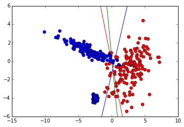

```python
x = np.linspace(-15,10,200)
y = np.linspace(-6,6,200)
X0,Y0 = np.meshgrid(x, y)
Z0 = X0*beta_c_lda[0] + Y0*beta_c_lda[1] + beta_c_lda[2]
Z1 = beta_c_log[0]*X0 + beta_c_log[1]*Y0 + beta_c_log[2]
Z2 = beta_c_lin[0]*X0 + beta_c_lin[1]*Y0 + beta_c_lin[2] - 0.5
pylab.plot(X_c[Y_c==1][:,0],X_c[Y_c==1][:,1],'bo',X_c[Y_c==0][:,0],X_c[Y_c==0][:,1],'ro')
pylab.contour(X0,Y0,Z0,1,colors='r')
pylab.contour(X0,Y0,Z1,1,colors='b')
pylab.contour(X0,Y0,Z2,1,colors='g')
```

Data set C: Logisitic and linear regression give better result due to the fact that the goal is to improve directly the classification error, while the LDA fits a model to the data, the deduce the classification, which explains the poor performance in the case of data that doesn't fit to the LDA model.

### 5 - QDA model

Using bayes formula we derive the expression: $P(y=1|x) = \frac{1}{\exp{-(x^T\textbf{A}x + \textbf{B}x+\alpha)}+1}$  
Where $\textbf{A} = \frac{1}{2}(\Sigma_2^{-1} - \Sigma_1^{-1})$ and $\textbf{B} = \mu_1^T\Sigma_1^{-1} - \mu_2^T\Sigma_2^{-1}$ and $\alpha = \frac{1}{2}(\mu_2^T\Sigma_2^{-1}\mu_2 - \mu_1^T\Sigma_1^{-1}\mu_1)$

** (a) **

```python
# This function trains a QDA model
def qda_train(X,Y):
    class1 = X[Y == 1]
    class2 = X[Y == 0]
    p1 = np.mean(Y==1)
    mean1 = class1.mean(0)
    mean2 = class2.mean(0)
    sigma1 = (class1-mean1).T.dot(class1-mean1)/len(class1)
    sigma2 = (class2-mean2).T.dot(class2-mean2)/len(class2)
    sigma1_inv = linalg.inv(sigma1)
    sigma2_inv = linalg.inv(sigma2)
    A = 0.5*(sigma2_inv - sigma1_inv)
    B = mean1.T.dot(sigma1_inv) - mean2.T.dot(sigma2_inv)
    alpha = 0.5*(mean2.T.dot(sigma2_inv).dot(mean2) - mean1.T.dot(sigma1_inv).dot(mean1)) + np.log(p1/(1-p1))
    return A,B,alpha
```

```python
# Train QDA model on the trainC dataset
A,B,alpha = qda_train(X_c[:,(0,1)],Y_c)
```

**(b)** We can now visualize the data with decision boundary

```
<a list of 7 text.Text objects>
```

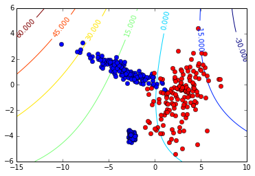

```python
Z0 = A[0,0]*(X0**2) + (A[1,0]+A[0,1])*X0*Y0 + A[1,1]*(Y0**2) + B[0]*X0 + B[1]*Y0 + alpha
pylab.plot(X_c[Y_c==1][:,0],X_c[Y_c==1][:,1],'bo',X_c[Y_c==0][:,0],X_c[Y_c==0][:,1],'ro')
cs = pylab.contour(X0,Y0,Z0)
pylab.clabel(cs)
```

Data set C

** (c) ** The misclassification error

```python
X_c = X_c[:,(0,1)]
Y_c_pred = (np.diag(X_c.dot(A).dot(X_c.T)) + X_c.dot(B) + alpha >= 0)
err_qda = np.mean(Y_c != Y_c_pred)
err_qda
```

```
0.052499999999999998
```

**(d) Comments**